# Basic building footprint calculations

October 23, 2020

The `foot` package was developed by WorldPop at the University of Southampton (www.worldpop.org) to provide a set of consistent and flexible tools for processing 2D vector representations of buildings (e.g. “footprints”) and calculating urban morphology measurements. The functionality includes basic geometry and morphology characteristics, distance and clustering metrics. These calculations are supported with helper functions for spatial intersections and tiled reading/writing of data.

```r
library(foot)
```

This vignette will demonstrate some of the core functionality in the package, including:

- The available measurements and summary statistics
- How to define different types of spatial zones for area-level summaries
- Calculating multiple summary metrics for a set of spatial areas
- Example workflows to produce outputs using `foot::calculate_footstats()`.

To demonstrate the package, this vignette will use a supplied sample of building footprint polygons produced by Microsoft Bing Maps ([Source](https://github.com/microsoft/Uganda-Tanzania-Building-Footprints)) from an area in Kampala, Uganda. These footprints have been reprocessed into a spatial data format which can be read with `sf`.

## Load the sample dataset

```r
data("kampala", package = "foot")

buildings <- kampala$buildings
adminzones <- kampala$adminZones
clusters <- kampala$clusters
```

Note that the adminZones and cluster boundaries are purely artificial and were created for demonstration purposes only.

For more information, see `?kampala`.

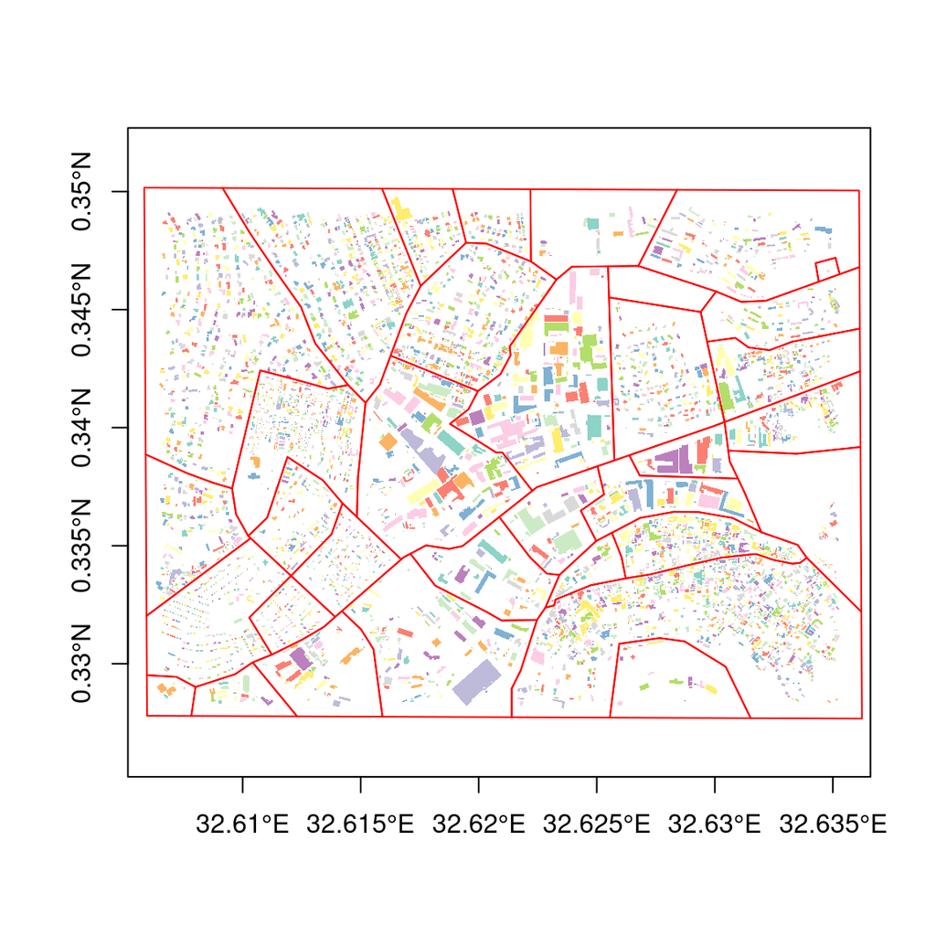

Sample buildings and zones in Kampala

## Calculations with `foot`

The core functions of `foot` are provided by `calculate_footstats()`. The operations include: 1) calculating geometry measures for each footprint, 2) summarising one or more geometry measures of footprints within zones. The simplest usage involves supplying a set of building footprint polygons and the desired characteristics to calculate. All operations return the same format - a `data.table`, optionally with a column for the index and the named column for the summarised footprint metric(s).

```r
# the area and perimeter of each building footprint
built_area <- calculate_footstats(buildings, what = list("area", "perimeter"))
```

```
#> Selecting metrics
#> Setting control values.
#> Pre-calculating areas
#> Pre-calculating perimeters
#> No summary functions found, returning metrics.
```

```r
head(built_area)
```

```
#>               area    perimeter
#> 1:  22.00824 [m^2] 19.26045 [m]
#> 2: 220.39011 [m^2] 67.95023 [m]
#> 3:  38.95750 [m^2] 25.37269 [m]
#> 4: 386.74429 [m^2] 98.55654 [m]
#> 5: 349.57765 [m^2] 82.22555 [m]
#> 6: 164.00931 [m^2] 55.87172 [m]
```

To summarise the footprint characteristics over all building polygons, the name of a summary function, or a list of multiple functions can be supplied.

```r
# the average and standard deviation of all building areas
calculate_footstats(buildings, what = "area", how = list("mean", "sd"))
```

```
#> Selecting metrics
#> Setting control values.
#> Pre-calculating areas
#>
#> Calculating  2  metrics ...
#>    area mean
#>    area sd
#> Finished calculating metrics.
#>    zoneID      area_mean area_sd
#> 1:      1 263.1865 [m^2]  715.28
```

### Available metrics and summary measures

Currently implemented are measures for:

- building presence
- area
- perimeter
- nearest neighbour distance
- angle of rotation
- compactness and shape

A table of metrics and other packaged summary function names available for each is available using `list_fs()`. The results of this function provide “cols” and “funs” which can be passed as `what` and `how` arguments, respectively, to `calculate_footstats`.

```r
# get all available built-in functions for perimeter calculations
argsList <- list_fs(what = "perimeter")

calculate_footstats(buildings, what = argsList$cols, how = argsList$funs)
```

```
#> Selecting metrics
#> Setting control values.
#> Pre-calculating perimeters
#>
#> Calculating  7  metrics ...
#>    perimeter cv
#>    perimeter max
#>    perimeter mean
#>    perimeter median
#>    perimeter min
#>    perimeter sd
#>    perimeter sum
#> Finished calculating metrics.
#>    zoneID perimeter_cv perimeter_max perimeter_mean perimeter_median
#> 1:      1    0.9396027  1089.097 [m]   62.22027 [m]     46.68314 [m]
#>    perimeter_min perimeter_sd perimeter_sum
#> 1:  14.88332 [m]     58.46233  301146.1 [m]
```

With no other argument supplied, all the footprints are treated as coming from the same spatial zone for any summary function. A later section describes the process for identifying zones.

## Additional characteristics and geometry measures

Whenever possible, `foot` makes use of generic functions within `R`. Most low-level geometry calculations rely on `sf` and `lwgeom` and users need to have recent versions of these packages installed. There are other stand-alone functions within `foot` to support more complex or less-common measurements.

### Nearest neighbour distances

Distances can be calculated between footprints, or between footprints and other spatial objects. The distances can be measured edge-to-edge (`method="poly"`) or the centroids of the building footprints can be used (`method="centroid"`).

```r
# nearest distance for the first 10 buildings to any other building measured
# between polygon edges
fs_nndist(buildings[1:10, ], buildings, maxSearch = 200, unit = "m")
```

```
#> Units: [m]
#>  [1]  3.961359  7.894813  1.019971 22.306277  2.484471 16.257603  0.951225
#>  [8]  1.864305  2.607113  2.291474
```

```r
# omitting argument 'Y' measures distance among the footprints supplied setting
# maxSearch=NULL removes the search restriction
fs_nndist(buildings[1:10, ], method = "centroid", maxSearch = NULL)
```

```
#> Units: [m]
#>  [1]  99.95859  99.95859  90.11091  90.11091 116.64498 116.64498 217.86037
#>  [8] 228.63068 217.86037 438.91352
```

Note that distance calculations are slower for polygons and for unprojected coordinate systems. The centroid-based calculations are fast. It is recommended that a maximum search radius is always used. Internally the calculations are done with a `data.table` to benefit from multi-threading capabilities.

### Rotation angles

A less conventional geometric measure is derived from the rotated bounding rectangle. This is the rectangle enclosing a footprint polygon which has been rotated to minimise the area. In contrast, a “bounding box” for a polygon is always oriented along the x and y axes.

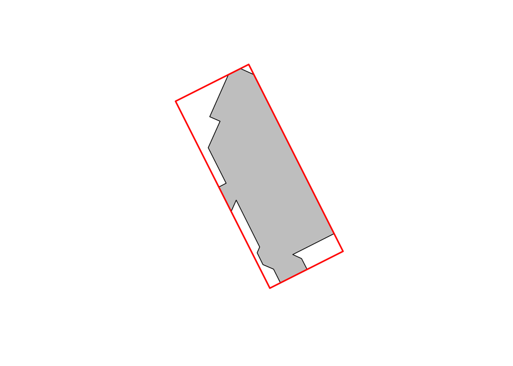

```r
# To obtain the rotated rectangle as a spatial object
mbr <- fs_mbr(buildings[4502, ], returnShape = T)

plot(sf::st_geometry(buildings[4502, ]), col = "grey")
plot(mbr, border = "red", lwd = 2, add = T)
```

```r
# Or obtain just the angle measure
fs_mbr(buildings[4502, ], returnShape = F)
```

```
#>        X
#> 63.25363
```

The angles can be summarised as an entropy measure and normalised to describe how much the angles of a set of structures depart from a regular grid pattern (available in `calculate_footstats` where `how="entropy"`).

## Creating and supplying zone indices

Rather than treating all footprints features as belonging to a single summary zone, it’s more common to want to summarise metrics within smaller areas. There are several ways to supply information on the zones.

### Index by vector

A vector of indices for the zones can be supplied to `foot` functions as a 1) column name within the footprints, 2) a standalone numeric vector of indices, or 3) a spatial polygons object to join to the building footprints. The length of a vector of indices must match the number of building polygons.

```r
# create a vector of ten random zones
idx <- sample(1:10, nrow(buildings), replace = T)
buildings$id <- idx  # add it to the buildings object
table(buildings$id)  # splitting observations into 10 groups
```

```
#>
#>   1   2   3   4   5   6   7   8   9  10
#> 488 470 475 470 503 480 491 491 498 474
```

```r
# 1. pass the index by name
colnames(buildings)
```

```
#> [1] "FID_1"    "geometry" "id"
```

```r
calculate_footstats(buildings, "id", what = "area", how = "mean", verbose = FALSE)
```

```
#>     id      area_mean
#>  1:  1 311.8235 [m^2]
#>  2:  2 258.5639 [m^2]
#>  3:  3 284.0431 [m^2]
#>  4:  4 257.0889 [m^2]
#>  5:  5 250.8175 [m^2]
#>  6:  6 225.4767 [m^2]
#>  7:  7 243.3985 [m^2]
#>  8:  8 294.7468 [m^2]
#>  9:  9 285.8606 [m^2]
#> 10: 10 218.1389 [m^2]
```

```r
# 2. pass the index as a standalone vector
calculate_footstats(buildings, idx, what = "settled", how = "count", verbose = FALSE)
```

```
#>     zoneID settled_count
#>  1:      1           488
#>  2:      2           470
#>  3:      3           475
#>  4:      4           470
#>  5:      5           503
#>  6:      6           480
#>  7:      7           491
#>  8:      8           491
#>  9:      9           498
#> 10:     10           474
```

```r
# 3. pass a separate spatial object of zones
calculate_footstats(buildings, zone = adminzones, what = "angle", how = "entropy",
    verbose = FALSE)
```

```
#>     zoneID angle_entropy
#>  1:      1     0.9351095
#>  2:      2     0.3108829
#>  3:      3     0.5849276
#>  4:      4     0.2003194
#>  5:      5     0.6678707
#>  6:      6     0.7139565
#>  7:      7     0.9691374
#>  8:      8     0.6102641
#>  9:      9     0.5110688
#> 10:     10     0.7309444
#> 11:     11     0.3933987
#> 12:     12     0.4602628
#> 13:     13     1.0000000
#> 14:     14     0.4656334
```

[output cut: 20 more lines]

### Index by zone shapes

Rather than supplying a pre-calculated column or vector of zonal indices, buildings can be assigned a zone based on a spatial join. When the index is created in the building footprints, it will be named “zoneID” or a user-specified name.

```r
# examine the other objects loaded from supplied data
head(adminzones)
```

```
#> Simple feature collection with 6 features and 1 field
#> geometry type:  POLYGON
#> dimension:      XY
#> bbox:           xmin: 32.60589 ymin: 0.3277355 xmax: 32.62531 ymax: 0.3388665
#> geographic CRS: WGS 84
#>   Id                       geometry
#> 1  1 POLYGON ((32.61231 0.327771...
#> 2  2 POLYGON ((32.61034 0.335317...
#> 3  3 POLYGON ((32.61592 0.327757...
#> 4  4 POLYGON ((32.6214 0.3277355...
#> 5  5 POLYGON ((32.62342 0.333760...
#> 6  6 POLYGON ((32.62498 0.335199...
```

```r
head(clusters)
```

```
#> Simple feature collection with 6 features and 1 field
#> geometry type:  POLYGON
#> dimension:      XY
#> bbox:           xmin: 32.60624 ymin: 0.3303863 xmax: 32.63375 ymax: 0.3472696
#> geographic CRS: WGS 84
#>   Id                       geometry
#> 1  1 POLYGON ((32.6066 0.3398617...
#> 2  2 POLYGON ((32.61151 0.337602...
#> 3  3 POLYGON ((32.61028 0.331954...
#> 4  4 POLYGON ((32.61649 0.344649...
#> 5  5 POLYGON ((32.62552 0.345516...
#> 6  6 POLYGON ((32.63225 0.340927...
```

```r
# Return a table of index values based on administrative zone polygons using the
# standalone function within `foot`
zID <- zonalIndex(buildings, adminzones, returnObject = F)
head(zID, 10)  # the xID column are row numbers to object X
```

```
#>      xID zoneID
#>  1:  145      1
#>  2:  338      1
#>  3:  655      1
#>  4:  995      1
#>  5: 2869      1
#>  6: 3164      1
#>  7: 3263      1
#>  8: 3314      1
#>  9: 3407      1
#> 10: 3454      1
```

```r
# Alternatively (and preferably), join zones to create a new footprint object A
# custom zone name can be used but must be specificed to the summary functions
zObj <- zonalIndex(buildings, clusters, zoneField = "Id", returnObject = T)
zObj
```

```
#> Simple feature collection with 348 features and 3 fields
#> geometry type:  POLYGON
#> dimension:      XY
#> bbox:           xmin: 32.60631 ymin: 0.328119 xmax: 32.63543 ymax: 0.349785
#> geographic CRS: WGS 84
#> First 10 features:
#>    FID_1 id Id                       geometry
#> 1   6293 10  1 POLYGON ((32.60744 0.338575...
#> 2  17706  7  1 POLYGON ((32.60664 0.339347...
#> 3  29106  1  1 POLYGON ((32.60719 0.339276...
#> 4  53393  2  1 POLYGON ((32.60779 0.339691...
#> 5  57187  2  1 POLYGON ((32.60826 0.338663...
#> 6  59496  1  1 POLYGON ((32.60692 0.339387...
#> 7  68588  5  1 POLYGON ((32.60791 0.338896...
#> 8  68590  7  1 POLYGON ((32.60768 0.339633...
#> 9  72387  1  1 POLYGON ((32.60777 0.338962...
#> 10 78504  8  1 POLYGON ((32.60702 0.338636...
```

When using a new spatial object which has been joined to its zones, remember to supply the name of the zone field to `calculate_foostats`.

```r
# use the new object and zone field 'Id' in a summary calculation
colnames(zObj)
```

```
#> [1] "FID_1"    "id"       "Id"       "geometry"
```

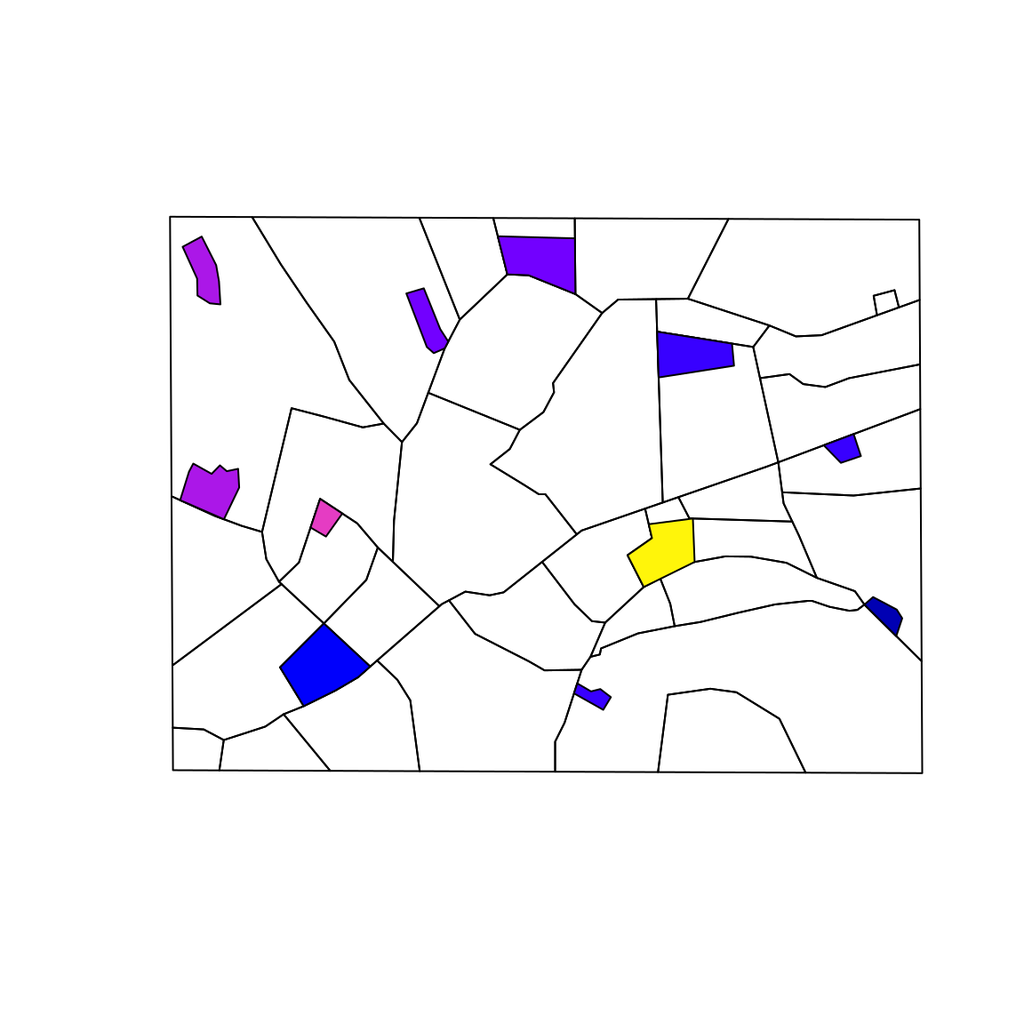

```r
zarea <- calculate_footstats(zObj, zone = "Id", what = "area", how = "mean", verbose = F)
clusters <- merge(clusters, zarea, by = "Id")
plot(sf::st_geometry(adminzones))
plot(clusters["area_mean"], add = T)
```

The `zonalIndex` function works by spatial intersection. This produces some (potentially useful) side effects that users need to be aware of. Specifically, note that if a building footprint intersects more than 1 zone it will be duplicated and associated to all intersecting zones.

The default behaviour (see `method`) is to assign a building to a zone based on its **centroid**.

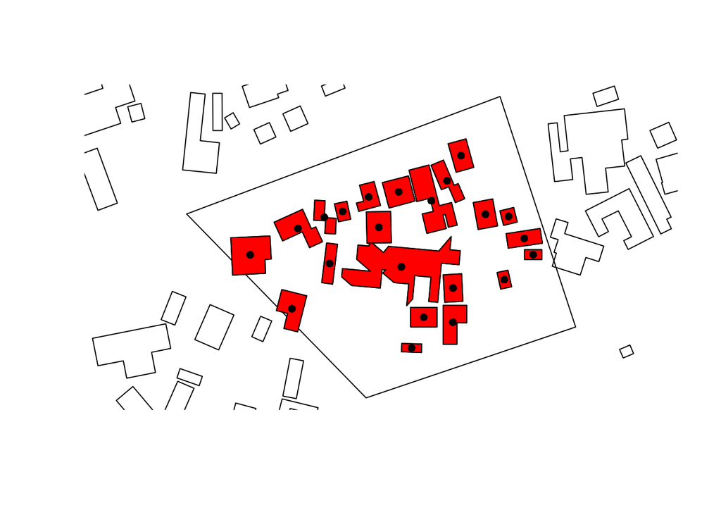

```r
# Note the selected structures extend beyond the cluster boundary
plot(sf::st_geometry(clusters)[[6]])
plot(sf::st_geometry(buildings), add = T)
plot(sf::st_geometry(zObj[zObj$Id == 6, ]), col = "red", add = T)
plot(sf::st_geometry(sf::st_centroid(zObj[zObj$Id == 6, ])), pch = 16, add = T)
```

Alternatively, an intersection can be used to assign footprints to any zones which are intersected. The whole footprint is associated, even if the shape is not “contained” by the zone.

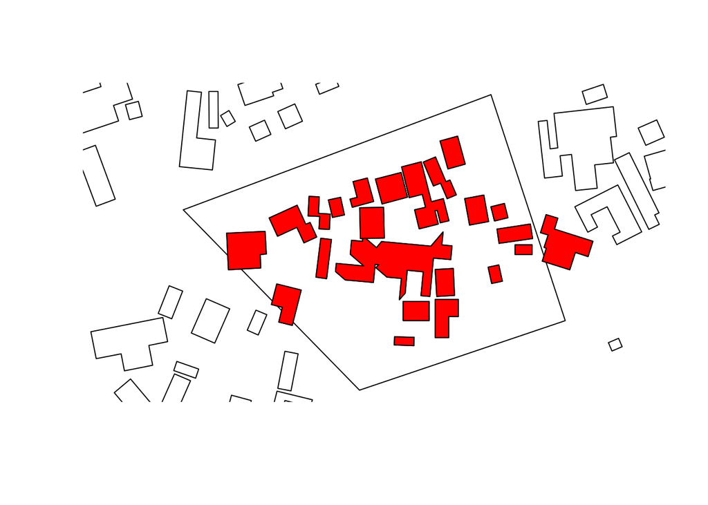

```r
# Note the selected structures extend beyond the cluster boundary
zInt <- zonalIndex(buildings, clusters, zoneField = "Id", method = "intersect")

plot(sf::st_geometry(clusters)[[6]])
plot(sf::st_geometry(buildings), add = T)
plot(sf::st_geometry(zInt[zInt$Id == 6, ]), col = "red", add = T)
```

Finally, the intersection can return a clipped set of buildings.

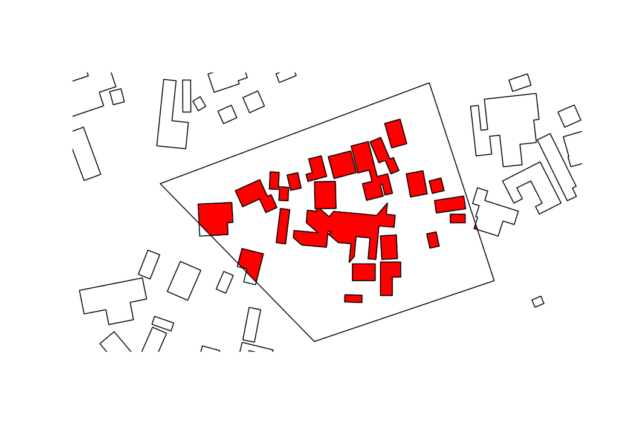

```r
zClip <- zonalIndex(buildings, clusters, zoneField = "Id", method = "clip")

plot(sf::st_geometry(clusters)[[6]])
plot(sf::st_geometry(buildings), add = T)
plot(sf::st_geometry(zClip[zClip$Id == 6, ]), col = "red", add = T)
```

This third option clips the footprints via intersection, potentially leaving small slivers of structures in the zone which will affect the feature statistics.

An additional side effect of the intersection operation is that overlapping zones are allowed, and this can duplicate and associate footprints into both (overlapping) zones.

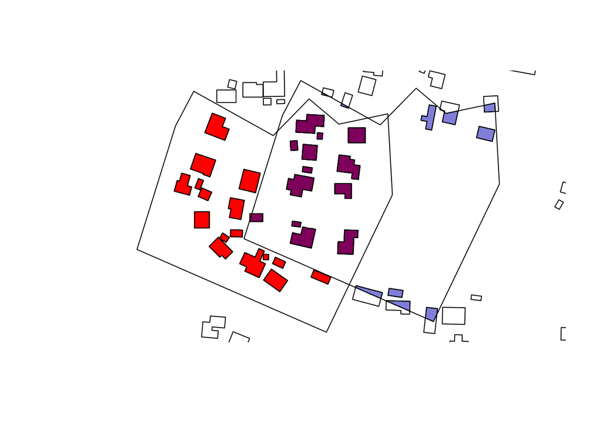

```r
# create a temporary shape by shifting one cluster
newClusters <- st_sfc(sf::st_geometry(clusters)[[1]], sf::st_cast(sf::st_geometry(clusters)[[1]] +
    c(0.001, 1e-04), "POLYGON"), crs = sf::st_crs(clusters))

newClusters <- st_sf(geometry = newClusters, crs = sf::st_crs(clusters))

newObj <- zonalIndex(buildings, newClusters, method = "clip")

# areas of overlap are in a purple hue
plot(sf::st_geometry(newClusters))
plot(sf::st_geometry(newObj[newObj$zoneID == 1, ]), col = "red", add = T)
plot(sf::st_geometry(newObj[newObj$zoneID == 2, ]), col = sf::sf.colors(n = 1, alpha = 0.5),
    add = T)
plot(sf::st_geometry(buildings), add = T)
```

These side effects are allowed because they allow for flexibility to support types of “focal” summaries of statistics and to produce a true gridded measure of footprint metrics.

## Calculating multiple metrics

The `calculate_footstats()` function provides a convenient wrapper to the individual footprint statistics and as well to `zonalIndex`. The function accepts a variety of input formats (see `?calculate_footstats`). Multiple metrics can be calculated for the same sets of buildings and zones.

```r
# Creates a zonal index and calculates multiple metrics
# Use the intersection method define zones
results <- calculate_footstats(buildings,
                               zone=adminzones,
                               what="area",
                               how=list("mean","cv"),
                               controlZone=list(method="intersect"),
                               verbose=F
                              )
  results
```

```
#>     zoneID        area_mean   area_cv
#>  1:      1  402.59838 [m^2] 1.2479809
#>  2:      2  211.05341 [m^2] 1.1069491
#>  3:      3  525.07469 [m^2] 1.9194754
#>  4:      4  555.09314 [m^2] 3.8206699
#>  5:      5  568.71544 [m^2] 1.7000587
#>  6:      6 1021.95294 [m^2] 2.0652377
#>  7:      7 2027.70402 [m^2] 1.4077033
#>  8:      8  908.24803 [m^2] 1.4225521
#>  9:      9  181.68220 [m^2] 1.6104922
#> 10:     10  251.99721 [m^2] 1.5272718
#> 11:     11  220.11253 [m^2] 1.4300230
#> 12:     12   87.83690 [m^2] 1.2659928
#> 13:     13  661.61890 [m^2] 1.7191007
#> 14:     14   81.85444 [m^2] 0.3447115
```

[output cut: 20 more lines]

Multiple metrics can be applied to specific groups of characteristics by providing nested lists of metrics and summary functions. The argument `what` will accept a string or a list of strings for specific metric names. Users may also supply `"all"` or `"nodist"` to calculate all available metrics or all bar the nearest neighbour distance-related ones, respectively. Excluding the distance-related metrics can speed up the calculations due to the long-running. Other performance improvements can be to set `controlDistance=list("method"="centroid")`, which uses centroid-to-centroid nearest neighbour distances rather than polygon edge-to-edge. See also, `?fs_nndist`.

```r
# Use nested lists to group characteristics and summary functions
results <- calculate_footstats(buildings,
                               zone=adminzones,
                               what=list(list("area","perimeter"),
                                         list("settled")),
                               how=list(list("sum","cv"),
                                        list("count")),
                               controlZone=list(method="centroid"),
                               verbose=F
                              )
  results
```

```
#>     zoneID          area_sum   perimeter_sum   area_cv perimeter_cv
#>  1:      1   8454.5661 [m^2]  1781.62245 [m] 1.2479809    0.6561304
#>  2:      2  29758.5314 [m^2]  8596.30974 [m] 1.1069491    0.7313348
#>  3:      3  25728.6600 [m^2]  4414.86934 [m] 1.9194754    0.9811076
#>  4:      4  63835.7113 [m^2]  9640.94681 [m] 3.8206699    1.0600954
#>  5:      5  26729.6259 [m^2]  4329.10334 [m] 1.7000587    0.9581201
#>  6:      6  35768.3531 [m^2]  3835.74843 [m] 2.0652377    0.9616081
#>  7:      7  28387.8563 [m^2]  2565.09927 [m] 1.4077033    0.9286094
#>  8:      8  44504.1537 [m^2]  6348.37632 [m] 1.4225521    0.8489816
#>  9:      9  48145.7825 [m^2] 15739.78807 [m] 1.6104922    0.9246860
#> 10:     10   7559.9164 [m^2]  2087.88260 [m] 1.5272718    1.0900293
#> 11:     11  24212.3780 [m^2]  7672.66021 [m] 1.4300230    0.8815988
#> 12:     12   3109.8042 [m^2]  1403.25960 [m] 1.3014215    0.7257624
#> 13:     13   2646.4756 [m^2]   423.87801 [m] 1.7191007    1.3165558
#> 14:     14   6712.0641 [m^2]  3088.40482 [m] 0.3447115    0.2059276
```

[output cut: 55 more lines]

### Filtering buildings

In some settings it may be preferable to exclude very small and/or very large building footprint polygons. The lower and upper bounds for filtering can be specified with `minArea` and `maxArea` in the `filter` argument. The values for these filters are in the same units specified by `controlUnits` or the default value for area calculations. Note that an “area” footprint statistic does not need to be requested as this characteristic is automatically calculated to enable filtering.

```r
# Filtering: # footprints must be larger than 50 m^2 and smaller than 1000 m^2
calculate_footstats(buildings,
                    what="perimeter",
                    how=list("mean", "sum"),
                    controlUnits=list(areaUnit="m^2"),
                    filter=list(minArea=50, maxArea=1000),
                    verbose=FALSE)
```

```
#>    zoneID perimeter_mean perimeter_sum
#> 1:      1   63.16899 [m]  228482.2 [m]
```

## Next steps

The `calculate_footstats` function provides the core functionality for calculating and summarising the characteristics of building footprints. It also wraps the functionality of assigning footprints to zones based on different spatial joining techniques. To go further with `foot` the concept of footprint morphology calculations can be extended to created gridded data. See `vignette("bigfoot", package="foot")`. Additionally, users can specify their own custom summary functions to be used with `calculate_footstats`. This and other advanced options are covered in `vignette("cobbler", package="foot")`.